# Project 1: RNAseq Pipeline Notebook

Sydney Sorbello

This is an [R Markdown](http://rmarkdown.rstudio.com) Notebook for Project 1 RNAseq. In this notebook we will first inspect the MultiQC results for quality. Next we can start our analysis by filtering the counts matrix. Then we will perform differential expression analysis and fgsea.

Let’s look at the [MultiQC Analysis](https://scc-ondemand1.bu.edu/rnode/scc-wi1/61978/file_show?path=%2Fprojectnb%2Fbf528%2Fstudents%2Fsorbello%2Fproject-1-sydneysorbello%2Fresults%2Fmultiqc_report.html) and analyze for overall quality. The Alignment statistics show a very good alignment percentage in which all samples are over 98%. The STAR alignment also reveals an slightly abnormal number of reads for the sample ‘control_rep_3’. This sample had a total of 118.9M reads whereas the other samples ranged from 84.5M to 106.9M. Although this is not necessarily a major red flag in the analysis, it is something we should take note of. Another indication that the STAR alignment was largley successful is that only a very small percentage of reads were mapped to too many loci or were un-mapped.

We can also look the the FastQC results for each sample. Since we are looking at RNAseq results, we expect to see a large number of duplicate reads. There is a good mix of single and duplicate reads for each sample, a good for for our results. FastQC also reveals the Sequence Quality Histograms. This feature allows us to look at the mean quality value across each base position in the read. For all of the samples we can see a high seqeunce quality across the reads. All of the samples also passed the per sequence quality score test. The per base sequence content test, however added a warning or failed the samples. This is most likely due to primer sequences that were used in the experiment, it does not indicate poor quality for an RNAseq experiment. Looking at the GC content we see roughly 50% on each of the samples; aligned with what is expected.

When looking at the top over-represented sequences, we can see they each have reads in the hundreds of thousands. The top over-represented sequence: ‘ATCGGAAGAGCACACGTCTGAACTCCAGTCACTAATACAGATCTCGTATG’ was put into BLAST. Although it wasn’t 100% identical to any gene, it shared 94.12% identity with a severe acute respiratory syndrome in Coronavirus 2 genome assembly. This may be an interesting find, but given every other quality measure looks ok, we can continue with analysis.

First, install the necessary packages:

```r
library(tidyverse)
library(dplyr)
library(DESeq2)
library(ggplot2)
```

Let’s take a look at the raw counts matrix:

```r
raw_counts<-read.csv(file = '/projectnb/bf528/students/sorbello/project-1-sydneysorbello/results/counts_matrix.csv')
head(raw_counts)
```

|  | gene | control_rep2_verse_counts | control_rep1_verse_counts | exp_rep2_verse_counts | exp_rep1_verse_counts | exp_rep3_verse_counts | control_rep3_verse_counts |
| --- | --- | --- | --- | --- | --- | --- | --- |
| 1 | ENSG00000290825.1 | 0 | 0 | 0 | 0 | 0 | 0 |
| 2 | ENSG00000223972.6 | 0 | 0 | 0 | 0 | 0 | 0 |
| 3 | ENSG00000227232.6 | 68 | 84 | 107 | 88 | 121 | 109 |
| 4 | ENSG00000278267.1 | 2 | 4 | 1 | 0 | 0 | 2 |
| 5 | ENSG00000243485.5 | 1 | 2 | 2 | 1 | 0 | 0 |
| 6 | ENSG00000284332.1 | 0 | 0 | 0 | 0 | 0 | 0 |

As we can see there’s a some reads that have a count of zero for each sample. In order to filter the counts, we will remove genes that have zero counts.

```r
filtered_counts <- raw_counts %>%
  filter(
    rowSums(across(-1)) != 0,
    rowMeans(across(-1)) >= 0.5
  )

head(filtered_counts)
```

|  | gene | control_rep2_verse_counts | control_rep1_verse_counts | exp_rep2_verse_counts | exp_rep1_verse_counts | exp_rep3_verse_counts | control_rep3_verse_counts |
| --- | --- | --- | --- | --- | --- | --- | --- |
| 1 | ENSG00000227232.6 | 68 | 84 | 107 | 88 | 121 | 109 |
| 2 | ENSG00000278267.1 | 2 | 4 | 1 | 0 | 0 | 2 |
| 3 | ENSG00000243485.5 | 1 | 2 | 2 | 1 | 0 | 0 |
| 4 | ENSG00000233750.3 | 1 | 1 | 3 | 4 | 3 | 2 |
| 5 | ENSG00000268903.1 | 17 | 19 | 27 | 19 | 17 | 24 |
| 6 | ENSG00000269981.1 | 13 | 18 | 16 | 10 | 31 | 27 |

In order to perform differential expression analysis with DESeq2, we need to correctly format the inputs:

```r
count_matrix <- filtered_counts %>%
  column_to_rownames("gene") %>%
  as.matrix()

sample_conditions <- data.frame(
  row.names = colnames(count_matrix),
  condition = c("control", "control", "experiment", "experiment", "experiment", "control")
)
```

Now let’s create the dataset for DESeq2:

```r
dds <- DESeqDataSetFromMatrix(
  countData = count_matrix,
  colData = sample_conditions,
  design = ~ condition
)
```

Now we can run differential expression analysis with DESeq2:

```r
dds <- DESeq(dds)
res <- results(dds)
```

```r
res_ordered <- res[order(res$padj), ]
head(res_ordered)
```

```
log2 fold change (MLE): condition experiment vs control
Wald test p-value: condition experiment vs control
DataFrame with 6 rows and 6 columns
                    baseMean log2FoldChange     lfcSE      stat       pvalue         padj
                   <numeric>      <numeric> <numeric> <numeric>    <numeric>    <numeric>
ENSG00000289575.1    737.511        3.60638  0.130254   27.6872 9.94692e-169 1.90961e-164
ENSG00000108439.11   428.272       -4.10259  0.164052  -25.0078 5.02520e-138 4.82368e-134
ENSG00000253846.3    489.648        4.44976  0.201711   22.0600 7.65459e-108 4.89842e-104
ENSG00000250616.4    522.057       -2.52250  0.121126  -20.8254  2.54889e-96  1.22334e-92
ENSG00000173262.12   599.448        4.59965  0.275765   16.6796  1.84475e-62  7.08309e-59
ENSG00000129824.16  6603.188       -8.24105  0.571440  -14.4215  3.78795e-47  1.21202e-43
```

Now that we have performed differential expression, let’s visualize the results. First we’ll make a volcano plot:

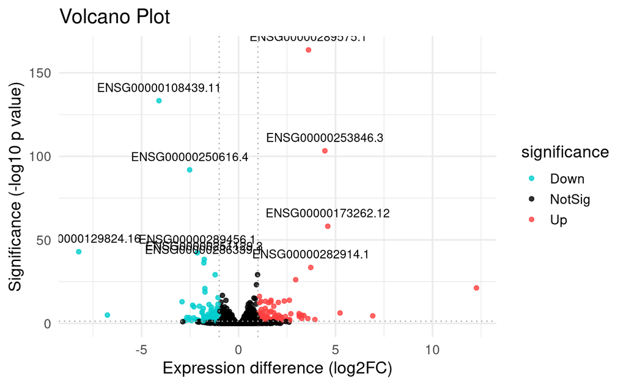

```r
res_df <- as.data.frame(res) %>%
  rownames_to_column("gene") %>%
  mutate(
    neg_log10_padj = -log10(padj),
    significance = case_when(
      padj < 0.05 & log2FoldChange > 1 ~ "Up",
      padj < 0.05 & log2FoldChange < -1 ~ "Down",
      TRUE ~ "NotSig"
    )
  )

# Show the 10 most significant gene names:
top_genes <- res_df %>%
  filter(significance != "NotSig") %>%
  arrange(padj) %>%
  slice_head(n = 10)

# and finally, plot the volcano plot:
ggplot(res_df, aes(x = log2FoldChange, y = neg_log10_padj)) +
  geom_point(aes(color = significance), alpha = 0.8) +
  scale_color_manual(values = c("Up" = "brown1", "Down" = "cyan3", "NotSig" = "black")) +
  geom_vline(xintercept = c(-1, 1), linetype = "dotted", color = "darkgray") +
  geom_hline(yintercept = -log10(0.05), linetype = "dotted", color = "darkgray") +
  geom_text(
    data = top_genes,
    aes(label = gene),
    vjust = -1, size = 3.5
  ) +
  labs(
    x = "Expression difference (log2FC)",
    y = "Significance (-log10 p value)",
    title = "Volcano Plot"
  ) +
  theme_minimal(base_size = 14)
```